# NASA Dataset Final Project

David Han

6/28/2019

## NASA Spatio-temporal Data

The data are geographic and atospheric measures on a very coarse 24 by 24 grid covering Central America. The data was obtained from the NASA Langley Research Center - Atmospheric Science Data Center.

## Storage

The data was stored in a data cube tbl from the dplyr package (tbl_cube). This type of data storage uses two arguments: dimensions and measures. The dimensions is a named list of vectors while measures is a named list of arrays.

Dimensions - latitude, longitude, month, and year.

Measures - Cloud coverage, ozone, surface temperature, temperature, and pressure.

```r
summary(nasa)
```

```
##      Length Class  Mode
## mets 7      -none- list
## dims 4      -none- list
```

## Variables

#### Latitude/Longitude

These two terms are used to specify precise locations of features on the surface of the Earth. In our case, 576 points were picked evenly spread on a 24 by 24 grid.

#### Month/Year

Each measure of data were measured every month for 6 years on all 576 locations.

#### Cloud Coverage

Cloud coverage refers to the fraction of the sky obscured by clouds from a particular location. The higher the number, the greatter the coverage. This piece of data was measured at three different levels: low, medium, and high per location.

#### Ozone

Ozone protects us from the sun’s UV rays and is measured in Dobson units (DU). Each Dobson unit refers to 0.01 millimeters of thickness. For reference, the ozone in the atmosphere is around 300 Dobsons.

#### Pressure

Pressure refers to the atmospheric pressure measured in millibars. For referece, the average pressure at sea level is around 1013 millibars.

#### Temperature

Temperature is the degree or intensity of heat in the atmosphere.The temperature is measured in Kelvin rather than Celsius or Fahrenheit.

#### Surface Temperature

Surface temperature is the temperature measured on the surface of Earth. This is also measured in Kelvin.

## Overview

```r
dfnasa <- as.data.frame(nasa)
year1 = slice(dfnasa,1,577,1153,1729,2305,2881,3457,4033,4609,5185,5761,6337)
```

Converted the nasa data into a data frame. Using slice(), I split the data into each year from 1995 to 2000.

Using the highcharter package, I created multiple line graphs to form basic relationships for each year.

#### Cloud Coverage

```r
highchart() %>%
  hc_xAxis(categories = year1$month) %>%
  hc_add_series(name = "High Cloud", data = year1$cloudhigh) %>%
  hc_add_series(name = "Low Cloud", data = year1$cloudlow) %>%
  hc_add_series(name = "Medium Cloud", data = year1$cloudmid) %>%
  hc_add_theme(hc_theme_538())
```

[interactive chart not shown]

Compares all of the cloud coverage (low, medium, high) into a line graph.

#### Temperatures and Ozone

```r
highchart() %>%
  hc_xAxis(categories = year1$month) %>%
  hc_add_series(name = "Temperature", data = year1$temperature) %>%
  hc_add_series(name = "Surface Temperature", data = year1$surftemp) %>%
  hc_add_series(name = "Ozone", data = year1$ozone) %>%
  hc_add_theme(hc_theme_economist())
```

[interactive chart not shown]

Compares the temperature, surface temperature and ozone layer using a line graph.

#### Air Pressure

```r
highchart() %>%
  hc_xAxis(categories = year1$month) %>%
  hc_add_series(name = "Pressure", data = year1$pressure) %>%
  hc_add_theme(hc_theme_ffx())
```

[interactive chart not shown]

Used a line graph to show any general trends of the pressure data.

## Using Latitudes and Longitudes

#### Temperature Distribution

```r
dflat = dfnasa$lat[1:576]
dflong = dfnasa$long[1:576]

qpal <- colorFactor(c("blue","royalblue","lightskyblue", "yellow","orange","red"),
                    domain = dfnasa$temperature[1:576])

leaflet(slice(dfnasa,1:576)) %>%
  addTiles() %>%
  setView(lng = -90, lat =  10, zoom = 3) %>%
  addCircleMarkers(lat = dflat, lng = dflong,color = ~qpal(temperature),
                   stroke = FALSE, fillOpacity= 0.3,
                   popup = paste("Temperature:", dfnasa$temperature))
```

[interactive chart not shown]

Using the leaflet package to create a map, I marked the temperatures of each region in the 24 by 24 grid. The red shows hotter temperatures while the blue shows cooler temperatures.

#### Air Pressure Distribution

```r
dflat = dfnasa$lat[1:576]
dflong = dfnasa$long[1:576]

qpal <- colorFactor(c("blue","yellow2","orange","firebrick1"),
                    domain = dfnasa$pressure[1:576])

leaflet(slice(dfnasa,1:576)) %>%
  addTiles() %>%
  setView(lng = -90, lat =  10, zoom = 3) %>%
  addCircleMarkers(lat = dflat, lng = dflong,color = ~qpal(pressure),
                   stroke = FALSE, fillOpacity= 0.5,
                   popup = paste("Pressure:",dfnasa$pressure))
```

[interactive chart not shown]

This map shows the distribution of air pressure across the 24 by 24 grid.

## Pearson’s Correlation

The purpose of the Pearson’s correlation was to make clearer relationships with the variables. As shown below, the positive, blue numbers show a positive correlation while the negative, red numbers show a negative correlation. The closer the number is to -1 or 1, the stronger the correlation.

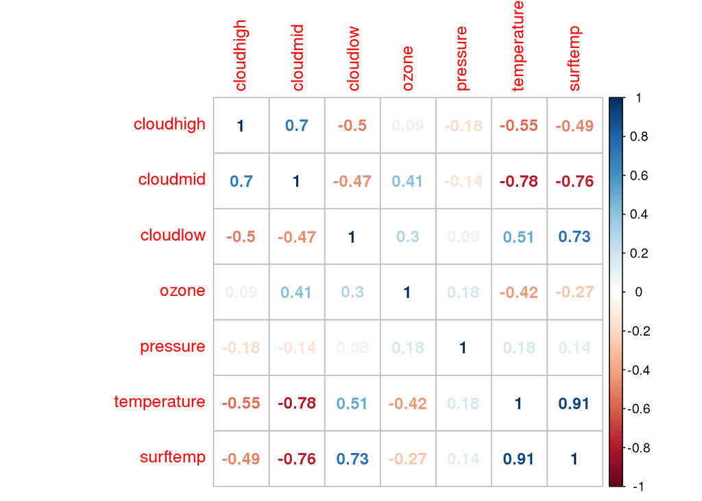

```r
selected_var <- combine %>%
  select(cloudhigh,cloudmid,cloudlow,ozone,pressure,temperature,surftemp)


corr_nasa <- cor(selected_var)
corrplot(corr_nasa,method = "number")
```